# Exploratory Data Analysis

Russel Luber

2025-11-04

```r
library(tidyverse)
library(here)
```

Load in the data

```r
d <- read_csv(here("data/clean/fight_data.csv"))
```

# Data Validation

Snapshot of the columns, col types, and values

```r
glimpse(d)
```

```
## Rows: 16,814
## Columns: 47
## $ source_url                   <chr> "http://ufcstats.com/fight-details/32927d…
## $ fight_id                     <chr> "32927d50acedb507", "58f6248da3cdf3ce", "…
## $ event_id                     <chr> "0e2c2daf11b5d8f2", "0e2c2daf11b5d8f2", "…
## $ event_name                   <chr> "UFC Fight Night: Garcia vs. Onama", "UFC…
## $ date                         <date> 2025-11-01, 2025-11-01, 2025-11-01, 2025…
## $ res                          <chr> "W", "W", "W", "W", "L", "L", "W", "W", "…
## $ fighter_id                   <chr> "87f8699fdcc2c404", "0e46690e55a8df75", "…
## $ fighter                      <chr> "Alice Ardelean", "Timmy Cuamba", "Charle…
## $ strikes_landed               <dbl> 146, 39, 163, 43, 58, 3, 79, 18, 59, 18, …
## $ strikes_thrown               <dbl> 288, 48, 214, 72, 121, 6, 122, 24, 84, 27…
## $ sig_strikes_landed           <dbl> 138, 23, 31, 33, 25, 0, 60, 12, 32, 10, 4…
## $ sig_strikes_thrown           <dbl> 280, 32, 38, 62, 83, 1, 100, 17, 53, 18, …
## $ volume_strikes_landed        <dbl> 8, 16, 132, 10, 33, 3, 19, 6, 27, 8, 7, 2…
```

[output cut: 34 more lines]

## String Clean Up

Remove leading and trailing whitespace in entries from columns that are strings (characters).

```r
d <- d %>%
  mutate(across(where(is.character), ~ str_trim(.x, side="both")))
```

## Duplicate Rows

I built a fighter-centric dataset, which means the key is `(fighter_id, fight_id)`: one row per fighter per fight. Let’s verify that.

Any duplicate rows?

```r
d %>% count(fighter_id, fight_id) %>% filter(n > 1)
```

```
## # A tibble: 0 × 3
## # ℹ 3 variables: fighter_id <chr>, fight_id <chr>, n <int>
```

No duplicate rows. Good.

## Check the Dates

According to [Wikipedia] (https://en.wikipedia.org/wiki/Ultimate_Fighting_Championship), the UFC was founded on November 12, 1993. Sanity check: there should be no fights in the dataset before that!

```r
d %>%
  summarise(
    earliest_fight = min(date),
    latest_fight = max(date)
  )
```

```
## # A tibble: 1 × 2
##   earliest_fight latest_fight
##   <date>         <date>
## 1 1994-03-11     2025-11-01
```

The earliest fight in the dataset happened on March 11, 1994. Great.

Just in case `summarise()` somehow missed anything:

```r
d %>%
  filter(date < as.Date("1993-11-12") | date > Sys.Date()) %>%
  arrange(date)
```

```
## # A tibble: 0 × 47
## # ℹ 47 variables: source_url <chr>, fight_id <chr>, event_id <chr>,
## #   event_name <chr>, date <date>, res <chr>, fighter_id <chr>, fighter <chr>,
## #   strikes_landed <dbl>, strikes_thrown <dbl>, sig_strikes_landed <dbl>,
## #   sig_strikes_thrown <dbl>, volume_strikes_landed <dbl>,
## #   volume_strikes_thrown <dbl>, strikes_avoided <dbl>,
## #   sig_strikes_avoided <dbl>, volume_strikes_avoided <dbl>, kds_scored <dbl>,
## #   tds_landed <dbl>, tds_attempted <dbl>, tds_stuffed <dbl>, …
```

Good. No fight data before the UFC was founded and no future fight data that hasn’t happened yet.

How many unique fights are there (that we have data on)?

```r
d %>%
  summarise(n_unique_fights = n_distinct(fight_id))
```

```
## # A tibble: 1 × 1
##   n_unique_fights
##             <int>
## 1            8407
```

8407 fights. Since there are two fighters involved in every match, we have 16814 rows in our `d` dataframe in total.

Are there missing values (`NANs`) in the data?

```r
d %>%
  summarise(across(everything(), ~ sum(is.na(.)))) %>%
  pivot_longer(
    cols = everything(),
    names_to = "column",
    values_to = "na_count"
  ) %>%
  arrange(desc(na_count))
```

```
## # A tibble: 47 × 2
##    column         na_count
##    <chr>             <int>
##  1 source_url            0
##  2 fight_id              0
##  3 event_id              0
##  4 event_name            0
##  5 date                  0
##  6 res                   0
##  7 fighter_id            0
##  8 fighter               0
##  9 strikes_landed        0
## 10 strikes_thrown        0
## # ℹ 37 more rows
```

No missing data across all entries of the 47 columns. - Need to review fetching and parsing scripts to ensure no missing data at this stage is a good thing. - For each of the columns, did I replace `NANs` with something else? Like a 0 maybe?

## Verify Results

Check that there are only four outcomes in each row of the `res` (result) column: Win (W), Loss (L), Draw (D), or No Contest (NC).

```r
d %>%
  distinct(res) %>%
  arrange(desc(res))
```

```
## # A tibble: 4 × 1
##   res
##   <chr>
## 1 W
## 2 NC
## 3 L
## 4 D
```

Good. There are only four outcomes, as expected.

In a fight, there are only 3 possible combinations of outcomes:

1. One fighter wins, the other loses.
2. The fight is ruled a draw, in which case both fighters get a “D” on their record.
3. The fight is a no contest, in which case both fighters get an “NC” on their record.

```r
res_patterns <- d %>%
  count(fight_id, res) %>%
  arrange(fight_id, res) %>%
  group_by(fight_id) %>%
  summarise(
    n_rows  = sum(n),
    pattern = paste0(res, ":", n, collapse = ","),
    .groups = "drop"
  ) %>%
  mutate(is_valid = n_rows == 2 & pattern %in% c("D:2", "NC:2", "L:1,W:1", "W:1,L:1"))

invalid_ids <- res_patterns %>% filter(!is_valid) %>% pull(fight_id)

offenders   <- d %>% filter(fight_id %in% invalid_ids)
```

```r
summarise(offenders)
```

```
## # A tibble: 1 × 0
```

```r
# Check that ALL fights (unique fight_id) have valid entries for the res column
d %>% distinct(fight_id) %>% count() %>% pull(n) %>% as.integer() == sum(res_patterns$is_valid)
```

```
## [1] TRUE
```

No fight had two winners or two losers or only one no contest (or draw). Every fight has a valid entry for the `res` column.

## Count Variables Cannot Be Negative

Variables like `strikes_landed`, `ctrl_time_s`, `td_stuffed`, and many (in fact most) of the variables in the dataset can be 0 but can’t be negative.

```r
summary_nonneg <- d %>%
  summarise(across(where(is.numeric), ~ sum(. < 0, na.rm = TRUE))) %>%
  tidyr::pivot_longer(everything(), names_to = "column", values_to = "n_negatives") %>%
  mutate(nonneg_ok = n_negatives == 0) %>%
  arrange(nonneg_ok, desc(n_negatives))

summary_nonneg
```

```
## # A tibble: 31 × 3
##    column                 n_negatives nonneg_ok
##    <chr>                        <int> <lgl>
##  1 strikes_landed                   0 TRUE
##  2 strikes_thrown                   0 TRUE
##  3 sig_strikes_landed               0 TRUE
##  4 sig_strikes_thrown               0 TRUE
##  5 volume_strikes_landed            0 TRUE
##  6 volume_strikes_thrown            0 TRUE
##  7 strikes_avoided                  0 TRUE
##  8 sig_strikes_avoided              0 TRUE
##  9 volume_strikes_avoided           0 TRUE
## 10 kds_scored                       0 TRUE
## # ℹ 21 more rows
```

Great. No negative counts slipped their way into the dataset somehow.

# Subsetting the Data

The [Unified Rules of Mixed Martial Arts](https://www.ufc.com/unified-rules-mixed-martial-arts) was adopted November 2000. So let’s start from there. Our data will include fights starting from UFC 28: High Stakes.

```r
unified_rules_adopted = "2000-11-01"
```

```r
d <- d %>%
  filter(date >= as.Date(unified_rules_adopted))
```

Let’s exclude fighters who’ve only fought once or twice.

```r
data <- d %>%
  distinct(fighter_id, fight_id, .keep_all = TRUE) %>%
  group_by(fighter_id) %>%
  filter(n_distinct(fight_id) >= 3) %>%
  ungroup()
```

Let’s inspect fighters who have only fought once or twice.

```r
newbs <- d %>%
  distinct(fighter_id, fight_id, .keep_all = TRUE) %>%
  group_by(fighter_id) %>%
  filter(n_distinct(fight_id) < 3) %>%
  ungroup()
```

There are 1069 rows for newbies (fighter-centric).

## Defining New Variables

Transform some variables to get striking accuracy measures.

The basic accuracy metric of each fighter, for each fight, will be the ratio between the amount of strikes (punches, kicks, knees, elbows) that hit the opponent and the total number of strikes they threw.

$$\text{striking accuracy} =
\frac{\text{strikes landed}}{\text{strikes thrown}}$$
Import caveat: What counts as a strike and how does the UFC count a strike? - There’s a lot of subjectivity to this. - The way it works it that there’s probably a few people at these live events whose job is to count the number of strikes thrown and landed. Then they review the footage afterward and correct their tallies, maybe? Not entirely sure. Need to read up on that. - What is the difference between a strike and a significant strike? What makes a strike significant? Need to understand that distinction.

```r
data <- data %>%
  # Retain striking and striking-relevant variables only + contextual variables for now
  select(
    -any_of(
      c("tds_landed", "tds_attempted", "tds_stuffed", "subs_attempted", "reversals", "ctrl_time_s",
        "tds_landed_by_opp", "subs_attempted_by_opp", "reversals_by_opp", "ctrl_time_s_for_opp")
      )
  ) %>%
  # Create striking metrics
  mutate(
    # Offensive strike metrics against opponent
    striking_accuracy = if_else(strikes_thrown > 0, strikes_landed / strikes_thrown, 0),
    sig_strikes_accuracy = if_else(sig_strikes_thrown > 0, sig_strikes_landed / sig_strikes_thrown, 0),
    sig_strikes_prop = if_else(sig_strikes_thrown > 0, sig_strikes_thrown / strikes_thrown, 0),
    volume_strikes_accuracy = if_else(volume_strikes_thrown > 0, volume_strikes_landed / volume_strikes_thrown, 0),
    # Defensive strike metrics for fighter
    strikes_avoided_prop = if_else(strikes_thrown_by_opp > 0, strikes_avoided / strikes_thrown_by_opp, 0),
    sig_strikes_avoided_prop = if_else(sig_strikes_thrown_by_opp > 0, sig_strikes_avoided / sig_strikes_thrown_by_opp, 0),
    volume_strikes_avoided_prop = if_else(volume_strikes_thrown_by_opp > 0,
                                          volume_strikes_avoided / volume_strikes_thrown_by_opp, 0),
    # Striking damage metrics against fighter
    strikes_absorbed_prop = if_else(strikes_thrown_by_opp > 0, strikes_landed_by_opp / strikes_thrown_by_opp, 0),
    sig_strikes_absorbed_prop = if_else(sig_strikes_thrown_by_opp > 0,
                                        sig_strikes_landed_by_opp/ sig_strikes_thrown_by_opp, 0),
    volume_strikes_absorbed_prop = if_else(volume_strikes_thrown_by_opp > 0,
                                           volume_strikes_landed_by_opp / volume_strikes_thrown_by_opp, 0)
  )
```

```r
data %>%
  summarise(mean_sig_strike_acc = mean(sig_strikes_accuracy, na.rm = TRUE),
            .by = fighter) %>%
  arrange(desc(mean_sig_strike_acc))
```

```
## # A tibble: 1,767 × 2
##    fighter              mean_sig_strike_acc
##    <chr>                              <dbl>
##  1 David Bielkheden                   0.826
##  2 Mark Weir                          0.760
##  3 Mackens Semerzier                  0.731
##  4 Francisco Figueiredo               0.726
##  5 Will Brooks                        0.726
##  6 Darrick Minner                     0.721
##  7 Jordan Leavitt                     0.711
##  8 Alistair Overeem                   0.704
##  9 Tom Aspinall                       0.701
## 10 Mounir Lazzez                      0.697
## # ℹ 1,757 more rows
```

## Preliminary Plots

```r
library(ggplot2)
```

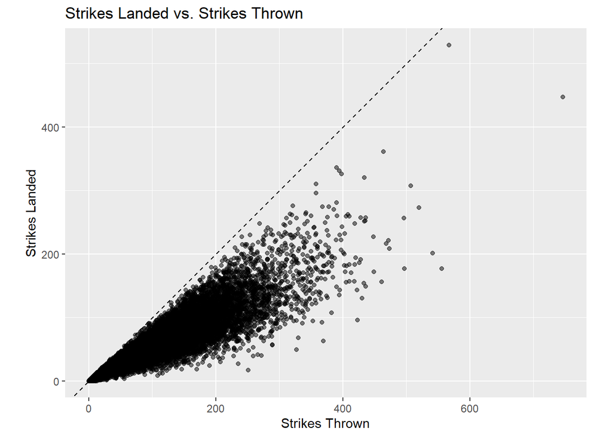

```r
# Strikes landed vs. strikes thrown - all fighters across all their fights
ggplot(data, aes(x = strikes_thrown, y = strikes_landed)) +
  geom_point(alpha = 0.5) +
  geom_abline(slope = 1, intercept = 0, linetype="dashed") +
  coord_equal() +
  labs(
    x = "Strikes Thrown",
    y = "Strikes Landed",
    title = "Strikes Landed vs. Strikes Thrown"
  )
```

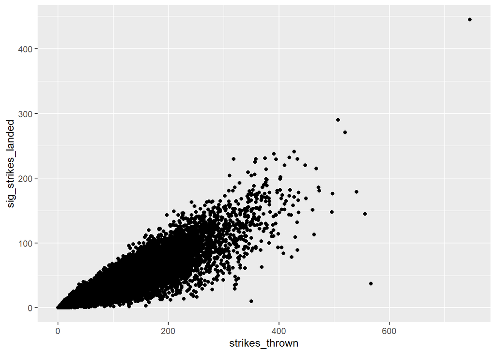

```r
# Significant strikes landed vs strikes thrown
ggplot(data, aes(x = strikes_thrown, y = sig_strikes_landed)) +
  geom_point()
```

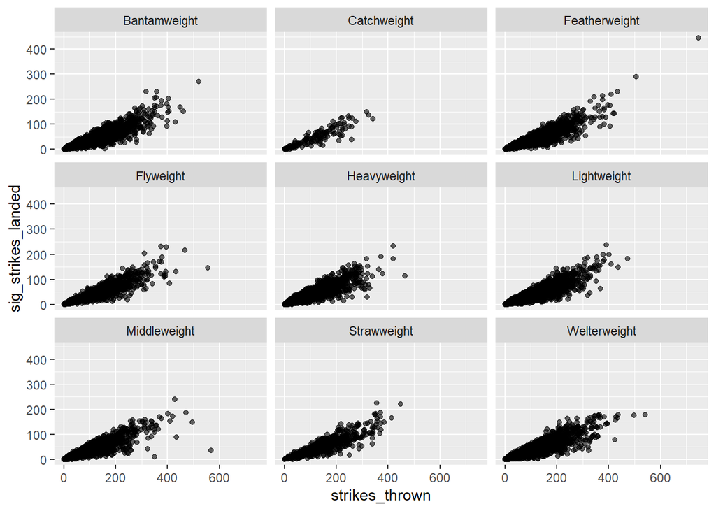

```r
# Strikes landed vs. strikes thrown by weight class
ggplot(data, aes(x = strikes_thrown, y = sig_strikes_landed)) +
  geom_point(alpha = 0.6) +
  facet_wrap(~ weight_class, ncol = 3)
```

Basic finding: Fighters thrown more than they land (obviously).

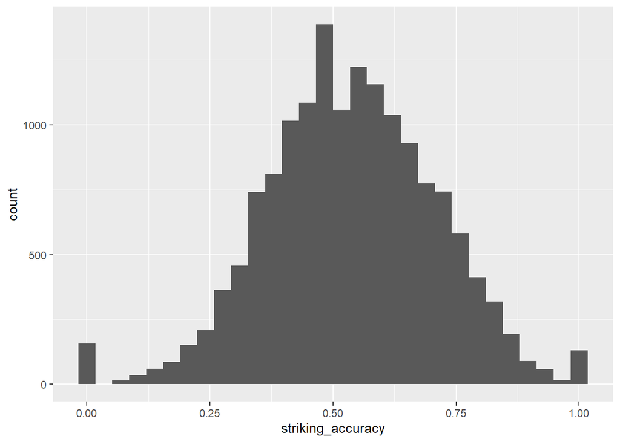

```r
ggplot(data, aes(striking_accuracy)) +
  geom_histogram(bins = 30)
```

Need to fix the 0.0 and 1.0 accuracies. 0 fights or 1 fight Andys.

Do fighters tend to land more than their opponent?

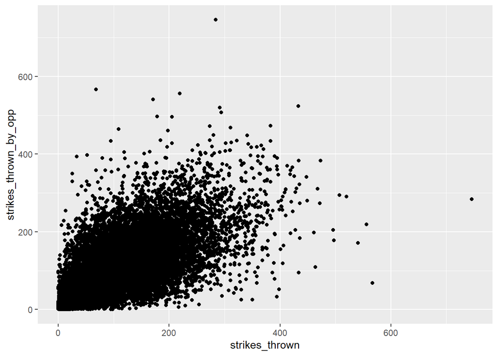

```r
ggplot(data, aes(x = strikes_thrown, y = strikes_thrown_by_opp)) +
  geom_point()
```

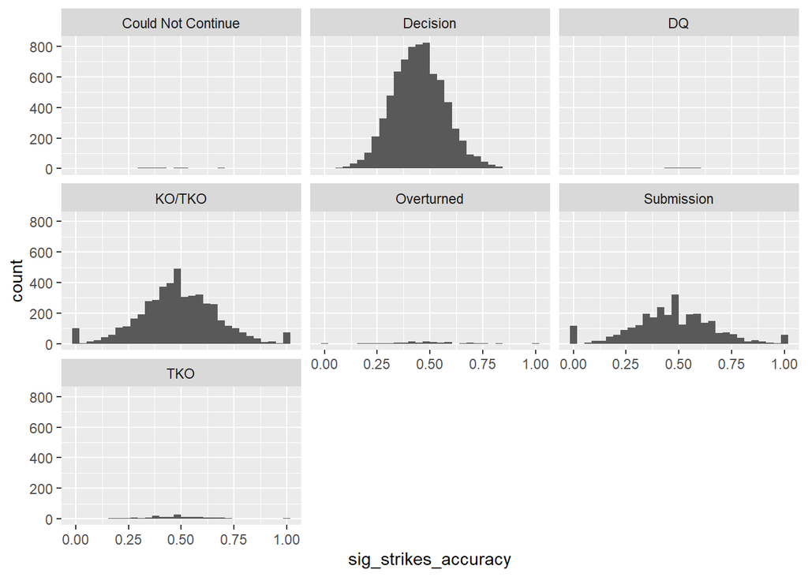

```r
ggplot(data, aes(sig_strikes_accuracy)) +
  geom_histogram(bins = 30) +
  facet_wrap(~ method)
```